> **Tip**: Welcome to the Investigate a Dataset project! You will find tips in quoted sections like this to help organize your approach to your investigation. Before submitting your project, it will be a good idea to go back through your report and remove these sections to make the presentation of your work as tidy as possible. First things first, you might want to double-click this Markdown cell and change the title so that it reflects your dataset and investigation.

# Project: FBI Gun Data Analysis

- Introduction
- Data Wrangling
- Exploratory Data Analysis
- Conclusions

## Introduction

> In this project we will be analyzing FBI gun data, the FBI National Instant Criminal Background Check System provide this data to us and it in range 1998 to 2017 . The data have two tables:

> > **●First dataset is called gun data os in .xlsx extention, it explains the type of guns that premit and registered, the states and the date that permit in.**

> > **●Second dataset is called U.S census data is in .csv extention, it explains some Facts like who buy and sell guns in states, this dataset is limited, so we will extract little information from it.**

> we will ask some research questions and after gathering and filterd datasets, the questions had to be answered

### Our Research Questions :

> **First question: Which highest state in permit?**

> **Second question: Which the highest state that the Persons 65 years and over, percent, April 1, 2010 is?**

> **Third question: Which month in the year have highest permit in guns?**

> **Fourth question: What the average of the all firms in 2012 for all states?**

> **Fifth question: What is the type of gun that have high totals in all states?**

> **Sixth question: What is the total of guns for all states and what the overall for gun growth?**

```python
import pandas as pd
import numpy as np
import matplotlib.pyplot as plt
%matplotlib inline
import seaborn as sns
```

## Data Wrangling

> **Tip**: In this section of the report, you will load in the data, check for cleanliness, and then trim and clean your dataset for analysis. Make sure that you document your steps carefully and justify your cleaning decisions.

### General Properties

```python
## Gathering guns data set
guns_df = pd.read_excel("gun_data.xlsx")
guns_df.head()
```

|  | month | state | permit | permit_recheck | handgun | long_gun | other | multiple | admin | prepawn_handgun | ... | returned_other | rentals_handgun | rentals_long_gun | private_sale_handgun | private_sale_long_gun | private_sale_other | return_to_seller_handgun | return_to_seller_long_gun | return_to_seller_other | totals |
| --- | --- | --- | --- | --- | --- | --- | --- | --- | --- | --- | --- | --- | --- | --- | --- | --- | --- | --- | --- | --- | --- |
| 0 | 2017-09 | Alabama | 16717.0 | 0.0 | 5734.0 | 6320.0 | 221.0 | 317 | 0.0 | 15.0 | ... | 0.0 | 0.0 | 0.0 | 9.0 | 16.0 | 3.0 | 0.0 | 0.0 | 3.0 | 32019 |
| 1 | 2017-09 | Alaska | 209.0 | 2.0 | 2320.0 | 2930.0 | 219.0 | 160 | 0.0 | 5.0 | ... | 0.0 | 0.0 | 0.0 | 17.0 | 24.0 | 1.0 | 0.0 | 0.0 | 0.0 | 6303 |
| 2 | 2017-09 | Arizona | 5069.0 | 382.0 | 11063.0 | 7946.0 | 920.0 | 631 | 0.0 | 13.0 | ... | 0.0 | 0.0 | 0.0 | 38.0 | 12.0 | 2.0 | 0.0 | 0.0 | 0.0 | 28394 |
| 3 | 2017-09 | Arkansas | 2935.0 | 632.0 | 4347.0 | 6063.0 | 165.0 | 366 | 51.0 | 12.0 | ... | 0.0 | 0.0 | 0.0 | 13.0 | 23.0 | 0.0 | 0.0 | 2.0 | 1.0 | 17747 |
| 4 | 2017-09 | California | 57839.0 | 0.0 | 37165.0 | 24581.0 | 2984.0 | 0 | 0.0 | 0.0 | ... | 0.0 | 0.0 | 0.0 | 0.0 | 0.0 | 0.0 | 0.0 | 0.0 | 0.0 | 123506 |

5 rows × 27 columns

> **Tip**: You should *not* perform too many operations in each cell. Create cells freely to explore your data. One option that you can take with this project is to do a lot of explorations in an initial notebook. These don't have to be organized, but make sure you use enough comments to understand the purpose of each code cell. Then, after you're done with your analysis, create a duplicate notebook where you will trim the excess and organize your steps so that you have a flowing, cohesive report.

> **Tip**: Make sure that you keep your reader informed on the steps that you are taking in your investigation. Follow every code cell, or every set of related code cells, with a markdown cell to describe to the reader what was found in the preceding cell(s). Try to make it so that the reader can then understand what they will be seeing in the following cell(s).

```python
## number of rows and columns
guns_df.shape
```

```
(12485, 27)
```

```python
## number of non-null cells
guns_df.info()
```

```
<class 'pandas.core.frame.DataFrame'>
RangeIndex: 12485 entries, 0 to 12484
Data columns (total 27 columns):
month                        12485 non-null object
state                        12485 non-null object
permit                       12461 non-null float64
permit_recheck               1100 non-null float64
handgun                      12465 non-null float64
long_gun                     12466 non-null float64
other                        5500 non-null float64
multiple                     12485 non-null int64
admin                        12462 non-null float64
prepawn_handgun              10542 non-null float64
prepawn_long_gun             10540 non-null float64
prepawn_other                5115 non-null float64
redemption_handgun           10545 non-null float64
redemption_long_gun          10544 non-null float64
redemption_other             5115 non-null float64
returned_handgun             2200 non-null float64
returned_long_gun            2145 non-null float64
returned_other               1815 non-null float64
rentals_handgun              990 non-null float64
rentals_long_gun             825 non-null float64
private_sale_handgun         2750 non-null float64
private_sale_long_gun        2750 non-null float64
private_sale_other           2750 non-null float64
return_to_seller_handgun     2475 non-null float64
return_to_seller_long_gun    2750 non-null float64
return_to_seller_other       2255 non-null float64
totals                       12485 non-null int64
dtypes: float64(23), int64(2), object(2)
memory usage: 2.6+ MB
```

```python
## number of null cells for each column
guns_df.isnull().sum()
```

```
month                            0
state                            0
permit                          24
permit_recheck               11385
handgun                         20
long_gun                        19
other                         6985
multiple                         0
admin                           23
prepawn_handgun               1943
prepawn_long_gun              1945
prepawn_other                 7370
redemption_handgun            1940
redemption_long_gun           1941
redemption_other              7370
returned_handgun             10285
returned_long_gun            10340
returned_other               10670
rentals_handgun              11495
rentals_long_gun             11660
private_sale_handgun          9735
private_sale_long_gun         9735
private_sale_other            9735
return_to_seller_handgun     10010
return_to_seller_long_gun     9735
return_to_seller_other       10230
totals                           0
dtype: int64
```

```python
# fill null cells with zero value to avoid logical errors
guns_df.fillna(0,inplace=True)
```

```python
guns_df.isnull().sum()
```

```
month                        0
state                        0
permit                       0
permit_recheck               0
handgun                      0
long_gun                     0
other                        0
multiple                     0
admin                        0
prepawn_handgun              0
prepawn_long_gun             0
prepawn_other                0
redemption_handgun           0
redemption_long_gun          0
redemption_other             0
returned_handgun             0
returned_long_gun            0
returned_other               0
rentals_handgun              0
rentals_long_gun             0
private_sale_handgun         0
private_sale_long_gun        0
private_sale_other           0
return_to_seller_handgun     0
return_to_seller_long_gun    0
return_to_seller_other       0
totals                       0
dtype: int64
```

```python
guns_df.duplicated().sum()
```

```
0
```

```python
guns_df.dtypes
```

```
month                         object
state                         object
permit                       float64
permit_recheck               float64
handgun                      float64
long_gun                     float64
other                        float64
multiple                       int64
admin                        float64
prepawn_handgun              float64
prepawn_long_gun             float64
prepawn_other                float64
redemption_handgun           float64
redemption_long_gun          float64
redemption_other             float64
returned_handgun             float64
returned_long_gun            float64
returned_other               float64
rentals_handgun              float64
rentals_long_gun             float64
private_sale_handgun         float64
private_sale_long_gun        float64
private_sale_other           float64
return_to_seller_handgun     float64
return_to_seller_long_gun    float64
return_to_seller_other       float64
totals                         int64
dtype: object
```

```python
## convert from object data type to datetime
guns_df['month']=pd.to_datetime(guns_df['month'])
```

```python
guns_df['month'].head()
```

```
0   2017-09-01
1   2017-09-01
2   2017-09-01
3   2017-09-01
4   2017-09-01
Name: month, dtype: datetime64[ns]
```

```python
guns_df.dtypes
```

```
month                        datetime64[ns]
state                                object
permit                              float64
permit_recheck                      float64
handgun                             float64
long_gun                            float64
other                               float64
multiple                              int64
admin                               float64
prepawn_handgun                     float64
prepawn_long_gun                    float64
prepawn_other                       float64
redemption_handgun                  float64
redemption_long_gun                 float64
redemption_other                    float64
returned_handgun                    float64
returned_long_gun                   float64
returned_other                      float64
rentals_handgun                     float64
rentals_long_gun                    float64
private_sale_handgun                float64
private_sale_long_gun               float64
private_sale_other                  float64
return_to_seller_handgun            float64
return_to_seller_long_gun           float64
return_to_seller_other              float64
totals                                int64
dtype: object
```

```python
guns_df.describe()
```

|  | permit | permit_recheck | handgun | long_gun | other | multiple | admin | prepawn_handgun | prepawn_long_gun | prepawn_other | ... | returned_other | rentals_handgun | rentals_long_gun | private_sale_handgun | private_sale_long_gun | private_sale_other | return_to_seller_handgun | return_to_seller_long_gun | return_to_seller_other | totals |
| --- | --- | --- | --- | --- | --- | --- | --- | --- | --- | --- | --- | --- | --- | --- | --- | --- | --- | --- | --- | --- | --- |
| count | 12485.000000 | 12485.000000 | 12485.000000 | 12485.000000 | 12485.000000 | 12485.000000 | 12485.000000 | 12485.000000 | 12485.000000 | 12485.000000 | ... | 12485.000000 | 12485.000000 | 12485.000000 | 12485.000000 | 12485.000000 | 12485.000000 | 12485.000000 | 12485.000000 | 12485.000000 | 12485.000000 |
| mean | 6401.300441 | 102.727433 | 5931.364277 | 7798.960833 | 158.798078 | 268.603364 | 58.789588 | 4.076652 | 6.613696 | 0.067841 | ... | 0.149379 | 0.006087 | 0.005767 | 3.289868 | 2.555707 | 0.226912 | 0.079696 | 0.097317 | 0.019143 | 21595.725911 |
| std | 23731.158830 | 2756.731662 | 8614.954626 | 9307.740581 | 913.339655 | 783.185073 | 604.262697 | 10.174706 | 15.395329 | 0.681467 | ... | 1.710795 | 0.179790 | 0.173912 | 33.987054 | 25.908792 | 2.139596 | 0.663611 | 0.740136 | 0.186114 | 32591.418387 |
| min | 0.000000 | 0.000000 | 0.000000 | 0.000000 | 0.000000 | 0.000000 | 0.000000 | 0.000000 | 0.000000 | 0.000000 | ... | 0.000000 | 0.000000 | 0.000000 | 0.000000 | 0.000000 | 0.000000 | 0.000000 | 0.000000 | 0.000000 | 0.000000 |
| 25% | 0.000000 | 0.000000 | 857.000000 | 2063.000000 | 0.000000 | 15.000000 | 0.000000 | 0.000000 | 0.000000 | 0.000000 | ... | 0.000000 | 0.000000 | 0.000000 | 0.000000 | 0.000000 | 0.000000 | 0.000000 | 0.000000 | 0.000000 | 4638.000000 |
| 50% | 511.000000 | 0.000000 | 3046.000000 | 5114.000000 | 0.000000 | 125.000000 | 0.000000 | 0.000000 | 0.000000 | 0.000000 | ... | 0.000000 | 0.000000 | 0.000000 | 0.000000 | 0.000000 | 0.000000 | 0.000000 | 0.000000 | 0.000000 | 12399.000000 |
| 75% | 4257.000000 | 0.000000 | 7277.000000 | 10374.000000 | 89.000000 | 301.000000 | 0.000000 | 3.000000 | 6.000000 | 0.000000 | ... | 0.000000 | 0.000000 | 0.000000 | 0.000000 | 0.000000 | 0.000000 | 0.000000 | 0.000000 | 0.000000 | 25453.000000 |
| max | 522188.000000 | 116681.000000 | 107224.000000 | 108058.000000 | 77929.000000 | 38907.000000 | 28083.000000 | 164.000000 | 269.000000 | 49.000000 | ... | 64.000000 | 12.000000 | 12.000000 | 1017.000000 | 777.000000 | 71.000000 | 28.000000 | 17.000000 | 4.000000 | 541978.000000 |

8 rows × 25 columns

```python
# Gathering U.S census data set
census_df = pd.read_csv('Census Data.csv')
census_df.head()
```

|  | Fact | Fact Note | Alabama | Alaska | Arizona | Arkansas | California | Colorado | Connecticut | Delaware | ... | South Dakota | Tennessee | Texas | Utah | Vermont | Virginia | Washington | West Virginia | Wisconsin | Wyoming |
| --- | --- | --- | --- | --- | --- | --- | --- | --- | --- | --- | --- | --- | --- | --- | --- | --- | --- | --- | --- | --- | --- |
| 0 | Population estimates, July 1, 2016, (V2016) | NaN | 4,863,300 | 741,894 | 6,931,071 | 2,988,248 | 39,250,017 | 5,540,545 | 3,576,452 | 952,065 | ... | 865454 | 6651194 | 27,862,596 | 3,051,217 | 624,594 | 8,411,808 | 7,288,000 | 1,831,102 | 5,778,708 | 585,501 |
| 1 | Population estimates base, April 1, 2010, (V2... | NaN | 4,780,131 | 710,249 | 6,392,301 | 2,916,025 | 37,254,522 | 5,029,324 | 3,574,114 | 897,936 | ... | 814195 | 6346298 | 25,146,100 | 2,763,888 | 625,741 | 8,001,041 | 6,724,545 | 1,853,011 | 5,687,289 | 563,767 |
| 2 | Population, percent change - April 1, 2010 (es... | NaN | 1.70% | 4.50% | 8.40% | 2.50% | 5.40% | 10.20% | 0.10% | 6.00% | ... | 0.063 | 0.048 | 10.80% | 10.40% | -0.20% | 5.10% | 8.40% | -1.20% | 1.60% | 3.90% |
| 3 | Population, Census, April 1, 2010 | NaN | 4,779,736 | 710,231 | 6,392,017 | 2,915,918 | 37,253,956 | 5,029,196 | 3,574,097 | 897,934 | ... | 814180 | 6346105 | 25,145,561 | 2,763,885 | 625,741 | 8,001,024 | 6,724,540 | 1,852,994 | 5,686,986 | 563,626 |
| 4 | Persons under 5 years, percent, July 1, 2016, ... | NaN | 6.00% | 7.30% | 6.30% | 6.40% | 6.30% | 6.10% | 5.20% | 5.80% | ... | 0.071 | 0.061 | 7.20% | 8.30% | 4.90% | 6.10% | 6.20% | 5.50% | 5.80% | 6.50% |

5 rows × 52 columns

```python
census_df.shape
```

```
(85, 52)
```

```python
census_df.duplicated().sum()
```

```
3
```

```python
census_df.drop_duplicates(inplace=True)
```

```python
census_df.duplicated().sum()
```

```
0
```

## Exploratory Data Analysis

> **Tip**: Now that you've trimmed and cleaned your data, you're ready to move on to exploration. Compute statistics and create visualizations with the goal of addressing the research questions that you posed in the Introduction section. It is recommended that you be systematic with your approach. Look at one variable at a time, and then follow it up by looking at relationships between variables.

### Research Question 1 (Which highest state in permit?)

```python
guns_df.columns
```

```
Index(['month', 'state', 'permit', 'permit_recheck', 'handgun', 'long_gun',
       'other', 'multiple', 'admin', 'prepawn_handgun', 'prepawn_long_gun',
       'prepawn_other', 'redemption_handgun', 'redemption_long_gun',
       'redemption_other', 'returned_handgun', 'returned_long_gun',
       'returned_other', 'rentals_handgun', 'rentals_long_gun',
       'private_sale_handgun', 'private_sale_long_gun', 'private_sale_other',
       'return_to_seller_handgun', 'return_to_seller_long_gun',
       'return_to_seller_other', 'totals'],
      dtype='object')
```

```python
# sum permit for all states
state_registrations=guns_df.groupby('state')['permit'].sum()
state_registrations
```

```
state
Alabama                  1047441.0
Alaska                     13352.0
Arizona                   710509.0
Arkansas                  507951.0
California               6530543.0
Colorado                  426970.0
Connecticut              1595270.0
Delaware                   22720.0
District of Columbia         330.0
Florida                  1088802.0
Georgia                  1786708.0
Guam                           0.0
Hawaii                    197321.0
Idaho                     369220.0
Illinois                 9498639.0
Indiana                  2965760.0
Iowa                     1467974.0
Kansas                    155471.0
Kentucky                24926779.0
Louisiana                  84376.0
Maine                      17260.0
Mariana Islands                0.0
Maryland                  345839.0
Massachusetts            1365225.0
Michigan                 3313076.0
Minnesota                2453637.0
Mississippi                99945.0
Missouri                  459241.0
Montana                   145138.0
Nebraska                  557192.0
Nevada                    212922.0
New Hampshire             409328.0
New Jersey                     0.0
New Mexico                 93241.0
New York                  804474.0
North Carolina           3872974.0
North Dakota              104526.0
Ohio                      372281.0
Oklahoma                       9.0
Oregon                     36899.0
Pennsylvania             1496008.0
Puerto Rico                    0.0
Rhode Island                   0.0
South Carolina            935319.0
South Dakota               36637.0
Tennessee                1130468.0
Texas                    2857582.0
Utah                     2753458.0
Vermont                        0.0
Virgin Islands             11485.0
Virginia                   25688.0
Washington               1668159.0
West Virginia              99018.0
Wisconsin                 768091.0
Wyoming                    78980.0
Name: permit, dtype: float64
```

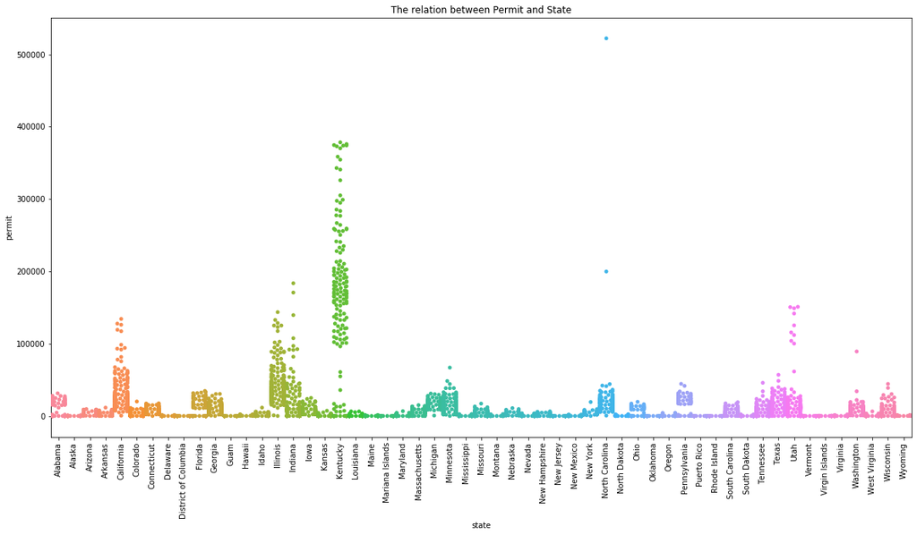

```python
plt.subplots(figsize=(20,10))
plt.xticks(rotation=90);
plt.title('The relation between Permit and State')
sns.swarmplot(x='state', y='permit', data=guns_df);
```

```
state
Kentucky          24926779.0
Illinois           9498639.0
California         6530543.0
North Carolina     3872974.0
Name: permit, dtype: float64
```

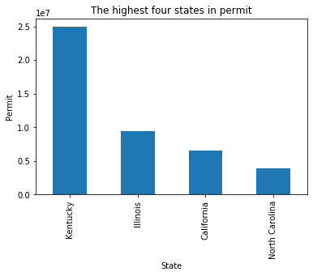

```python
state_registrations.nlargest(4).plot(kind='bar')
plt.xlabel('State')
plt.ylabel('Permit');
plt.title('The highest four states in permit')
state_registrations.nlargest(4)
```

```python
#high state of permit
print('the highest state of permits is: {} with permits: {} '.format(state_registrations.idxmax(),int(state_registrations.max())))
```

```
the highest state of permits is: Kentucky with permits: 24926779
```

### Research Question 2 (Which the highest state that the persons 65 years and over, percent, April 1, 2010 is? )

```python
census_df.head(8)
```

|  | Fact | Fact Note | Alabama | Alaska | Arizona | Arkansas | California | Colorado | Connecticut | Delaware | ... | South Dakota | Tennessee | Texas | Utah | Vermont | Virginia | Washington | West Virginia | Wisconsin | Wyoming |
| --- | --- | --- | --- | --- | --- | --- | --- | --- | --- | --- | --- | --- | --- | --- | --- | --- | --- | --- | --- | --- | --- |
| 0 | Population estimates, July 1, 2016, (V2016) | NaN | 4,863,300 | 741,894 | 6,931,071 | 2,988,248 | 39,250,017 | 5,540,545 | 3,576,452 | 952,065 | ... | 865454 | 6651194 | 27,862,596 | 3,051,217 | 624,594 | 8,411,808 | 7,288,000 | 1,831,102 | 5,778,708 | 585,501 |
| 1 | Population estimates base, April 1, 2010, (V2... | NaN | 4,780,131 | 710,249 | 6,392,301 | 2,916,025 | 37,254,522 | 5,029,324 | 3,574,114 | 897,936 | ... | 814195 | 6346298 | 25,146,100 | 2,763,888 | 625,741 | 8,001,041 | 6,724,545 | 1,853,011 | 5,687,289 | 563,767 |
| 2 | Population, percent change - April 1, 2010 (es... | NaN | 1.70% | 4.50% | 8.40% | 2.50% | 5.40% | 10.20% | 0.10% | 6.00% | ... | 0.063 | 0.048 | 10.80% | 10.40% | -0.20% | 5.10% | 8.40% | -1.20% | 1.60% | 3.90% |
| 3 | Population, Census, April 1, 2010 | NaN | 4,779,736 | 710,231 | 6,392,017 | 2,915,918 | 37,253,956 | 5,029,196 | 3,574,097 | 897,934 | ... | 814180 | 6346105 | 25,145,561 | 2,763,885 | 625,741 | 8,001,024 | 6,724,540 | 1,852,994 | 5,686,986 | 563,626 |
| 4 | Persons under 5 years, percent, July 1, 2016, ... | NaN | 6.00% | 7.30% | 6.30% | 6.40% | 6.30% | 6.10% | 5.20% | 5.80% | ... | 0.071 | 0.061 | 7.20% | 8.30% | 4.90% | 6.10% | 6.20% | 5.50% | 5.80% | 6.50% |
| 5 | Persons under 5 years, percent, April 1, 2010 | NaN | 6.40% | 7.60% | 7.10% | 6.80% | 6.80% | 6.80% | 5.70% | 6.20% | ... | 0.073 | 0.064 | 7.70% | 9.50% | 5.10% | 6.40% | 6.50% | 5.60% | 6.30% | 7.10% |
| 6 | Persons under 18 years, percent, July 1, 2016,... | NaN | 22.60% | 25.20% | 23.50% | 23.60% | 23.20% | 22.80% | 21.10% | 21.50% | ... | 0.246 | 0.226 | 26.20% | 30.20% | 19.00% | 22.20% | 22.40% | 20.50% | 22.30% | 23.70% |
| 7 | Persons under 18 years, percent, April 1, 2010 | NaN | 23.70% | 26.40% | 25.50% | 24.40% | 25.00% | 24.40% | 22.90% | 22.90% | ... | 0.249 | 0.236 | 27.30% | 31.50% | 20.70% | 23.20% | 23.50% | 20.90% | 23.60% | 24.00% |

8 rows × 52 columns

```python
## make the fact column as an index
index=census_df["Fact"]
census_df.set_index("Fact",inplace= True)
```

```python
census_df.head()
```

| Fact | Fact Note | Alabama | Alaska | Arizona | Arkansas | California | Colorado | Connecticut | Delaware | Florida | ... | South Dakota | Tennessee | Texas | Utah | Vermont | Virginia | Washington | West Virginia | Wisconsin | Wyoming |
| --- | --- | --- | --- | --- | --- | --- | --- | --- | --- | --- | --- | --- | --- | --- | --- | --- | --- | --- | --- | --- | --- |
| Population estimates, July 1, 2016, (V2016) | NaN | 4,863,300 | 741,894 | 6,931,071 | 2,988,248 | 39,250,017 | 5,540,545 | 3,576,452 | 952,065 | 20,612,439 | ... | 865454 | 6651194 | 27,862,596 | 3,051,217 | 624,594 | 8,411,808 | 7,288,000 | 1,831,102 | 5,778,708 | 585,501 |
| Population estimates base, April 1, 2010, (V2016) | NaN | 4,780,131 | 710,249 | 6,392,301 | 2,916,025 | 37,254,522 | 5,029,324 | 3,574,114 | 897,936 | 18,804,592 | ... | 814195 | 6346298 | 25,146,100 | 2,763,888 | 625,741 | 8,001,041 | 6,724,545 | 1,853,011 | 5,687,289 | 563,767 |
| Population, percent change - April 1, 2010 (estimates base) to July 1, 2016, (V2016) | NaN | 1.70% | 4.50% | 8.40% | 2.50% | 5.40% | 10.20% | 0.10% | 6.00% | 9.60% | ... | 0.063 | 0.048 | 10.80% | 10.40% | -0.20% | 5.10% | 8.40% | -1.20% | 1.60% | 3.90% |
| Population, Census, April 1, 2010 | NaN | 4,779,736 | 710,231 | 6,392,017 | 2,915,918 | 37,253,956 | 5,029,196 | 3,574,097 | 897,934 | 18,801,310 | ... | 814180 | 6346105 | 25,145,561 | 2,763,885 | 625,741 | 8,001,024 | 6,724,540 | 1,852,994 | 5,686,986 | 563,626 |
| Persons under 5 years, percent, July 1, 2016, (V2016) | NaN | 6.00% | 7.30% | 6.30% | 6.40% | 6.30% | 6.10% | 5.20% | 5.80% | 5.50% | ... | 0.071 | 0.061 | 7.20% | 8.30% | 4.90% | 6.10% | 6.20% | 5.50% | 5.80% | 6.50% |

5 rows × 51 columns

```python
# the highest purchages states for the persons under 18 years, percent, July 1, 2016
# some state not in percentage % style and all in string data type
states_purchages = census_df.loc['Persons 65 years and over, percent, April 1, 2010','Alabama':]
states_purchages
```

```
Alabama           13.80%
Alaska             7.70%
Arizona           13.80%
Arkansas          14.40%
California        11.40%
Colorado          10.90%
Connecticut       14.20%
Delaware          14.40%
Florida           17.30%
Georgia           10.70%
Hawaii            14.30%
Idaho             12.40%
Illinois          12.50%
Indiana           13.00%
Iowa              14.90%
Kansas            13.20%
Kentucky          13.30%
Louisiana         12.30%
Maine             15.90%
Maryland          12.30%
Massachusetts     13.80%
Michigan          13.80%
Minnesota         12.90%
Mississippi       12.80%
Missouri          14.00%
Montana           14.80%
Nebraska          13.50%
Nevada            12.00%
New Hampshire     13.50%
New Jersey        13.50%
New Mexico         0.132
New York           0.135
North Carolina     0.129
North Dakota       0.145
Ohio               0.141
Oklahoma           0.135
Oregon             0.139
Pennsylvania       0.154
Rhode Island       0.144
South Carolina     0.137
South Dakota       0.143
Tennessee          0.134
Texas             10.30%
Utah               9.00%
Vermont           14.60%
Virginia          12.20%
Washington        12.30%
West Virginia     16.00%
Wisconsin         13.70%
Wyoming           12.40%
Name: Persons 65 years and over, percent, April 1, 2010, dtype: object
```

```python
# clean states_purchages from '%', convert to float to find max value easily
# and make all in percentage style to be in the same range
states_purchages=states_purchages.str.split('%',expand=True)[0].astype(float).map(lambda a: a if (a > 1) else a*100)
states_purchages
```

```
Alabama           13.8
Alaska             7.7
Arizona           13.8
Arkansas          14.4
California        11.4
Colorado          10.9
Connecticut       14.2
Delaware          14.4
Florida           17.3
Georgia           10.7
Hawaii            14.3
Idaho             12.4
Illinois          12.5
Indiana           13.0
Iowa              14.9
Kansas            13.2
Kentucky          13.3
Louisiana         12.3
Maine             15.9
Maryland          12.3
Massachusetts     13.8
Michigan          13.8
Minnesota         12.9
Mississippi       12.8
Missouri          14.0
Montana           14.8
Nebraska          13.5
Nevada            12.0
New Hampshire     13.5
New Jersey        13.5
New Mexico        13.2
New York          13.5
North Carolina    12.9
North Dakota      14.5
Ohio              14.1
Oklahoma          13.5
Oregon            13.9
Pennsylvania      15.4
Rhode Island      14.4
South Carolina    13.7
South Dakota      14.3
Tennessee         13.4
Texas             10.3
Utah               9.0
Vermont           14.6
Virginia          12.2
Washington        12.3
West Virginia     16.0
Wisconsin         13.7
Wyoming           12.4
Name: 0, dtype: float64
```

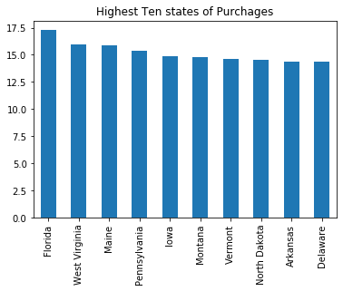

```python
# highest states
states_purchages.nlargest(10).plot(kind='bar',title="Highest Ten states of Purchages")
```

```python
highest_purchages_value =states_purchages.max()
print('the highest purchages value is: ',highest_purchages_value)
```

```
the highest purchages value is:  17.3
```

```python
#Highest purchages state happened for the persons under 18 years, percent, July 1, 2016
highest_purchages_state =states_purchages.idxmax()
print('the highest purchages state is: ',highest_purchages_state)
```

```
the highest purchages state is:  Florida
```

### Research Question 3 (Which month in the year have highest permit in guns? )

```python
#create ne column called month and add the name of months to it
guns_df['months'] = guns_df['month'].dt.strftime("%B")
```

```python
# sum all perimts for each month in all years
months_permits=guns_df.groupby('months',sort=True)['permit'].sum()
months_permits
```

```
months
April        7150292.0
August       6247928.0
December     6516956.0
February     7114356.0
January      7370400.0
July         6420573.0
June         6391413.0
March        8306293.0
May          6566366.0
November     5732256.0
October      6017871.0
September    6085532.0
Name: permit, dtype: float64
```

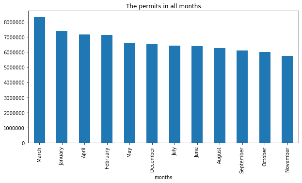

```python
months_permits.nlargest(12).plot(kind='bar',figsize=(10,5),title='The permits in all months')
```

**the month of highest permit**

```python
print('the month of highest permit is: {} with permits: {} '.format(months_permits.idxmax(),int(months_permits.max())))
```

```
the month of highest permit is: March with permits: 8306293
```

### Research Question 4 (What the average of the all firms in 2012 for all states?)

```python
all_firms = census_df.loc['All firms, 2012','Alabama':]
all_firms
```

```
Alabama             374,153
Alaska               68,032
Arizona             499,926
Arkansas            231,959
California        3,548,449
Colorado            547,352
Connecticut         326,693
Delaware             73,418
Florida           2,100,187
Georgia             929,864
Hawaii              118,454
Idaho               146,642
Illinois          1,135,017
Indiana             479,059
Iowa                259,121
Kansas              239,118
Kentucky            331,546
Louisiana           414,291
Maine               139,570
Maryland            531,953
Massachusetts       607,664
Michigan            834,087
Minnesota           489,494
Mississippi         235,454
Missouri            491,606
Montana             112,419
Nebraska            164,089
Nevada              227,156
New Hampshire       131,638
New Jersey          792,088
New Mexico           151363
New York            2008988
North Carolina       805985
North Dakota          68270
Ohio                 904814
Oklahoma             327229
Oregon               339305
Pennsylvania         975453
Rhode Island          94642
South Carolina       367726
South Dakota          81314
Tennessee            550453
Texas             2,356,748
Utah                251,419
Vermont              75,827
Virginia            653,193
Washington          541,522
West Virginia       114,435
Wisconsin           432,980
Wyoming              62,427
Name: All firms, 2012, dtype: object
```

```python
all_firms.dtypes
```

```
dtype('O')
```

```python
all_firms.shape
```

```
(50,)
```

```python
# delete comma to calculate the average truely
all_firms.replace(',','',regex=True,inplace=True)
all_firms
```

```
Alabama            374153
Alaska              68032
Arizona            499926
Arkansas           231959
California        3548449
Colorado           547352
Connecticut        326693
Delaware            73418
Florida           2100187
Georgia            929864
Hawaii             118454
Idaho              146642
Illinois          1135017
Indiana            479059
Iowa               259121
Kansas             239118
Kentucky           331546
Louisiana          414291
Maine              139570
Maryland           531953
Massachusetts      607664
Michigan           834087
Minnesota          489494
Mississippi        235454
Missouri           491606
Montana            112419
Nebraska           164089
Nevada             227156
New Hampshire      131638
New Jersey         792088
New Mexico         151363
New York          2008988
North Carolina     805985
North Dakota        68270
Ohio               904814
Oklahoma           327229
Oregon             339305
Pennsylvania       975453
Rhode Island        94642
South Carolina     367726
South Dakota        81314
Tennessee          550453
Texas             2356748
Utah               251419
Vermont             75827
Virginia           653193
Washington         541522
West Virginia      114435
Wisconsin          432980
Wyoming             62427
Name: All firms, 2012, dtype: object
```

**The average of all firms in 2012 of all states**

```python
print ('The average of all firms in 2012 of all states: ',all_firms.astype(int).mean())
```

```
The average of all firms in 2012 of all states:  554891.84
```

### Research Question 5 (What is the type of gun that have high totals in all states?)

```python
guns_type = {}
col = guns_df.columns[2:]
for i in col:
    if 'gun' in i:
        guns_type[i] = guns_df[i].sum()
guns_type
```

```
{'handgun': 74053083.0,
 'long_gun': 97370026.0,
 'prepawn_handgun': 50897.0,
 'prepawn_long_gun': 82572.0,
 'redemption_handgun': 4302048.0,
 'redemption_long_gun': 6319361.0,
 'returned_handgun': 65148.0,
 'returned_long_gun': 16211.0,
 'rentals_handgun': 76.0,
 'rentals_long_gun': 72.0,
 'private_sale_handgun': 41074.0,
 'private_sale_long_gun': 31908.0,
 'return_to_seller_handgun': 995.0,
 'return_to_seller_long_gun': 1215.0}
```

**the type of gun has highest quantity**

```python
type_of_highest_quantity_gun = max(guns_type,key=guns_type.get)
print('the type of gun has highest quantity is: ',type_of_highest_quantity_gun.replace("_"," ").title())
```

```
the type of gun has highest quantity is:  Long Gun
```

**the relation between the type of gun has highest quantity and totals**

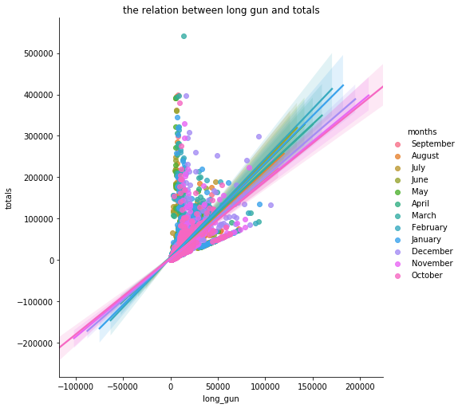

```python
sns.lmplot(x = type_of_highest_quantity_gun, y = 'totals', hue = 'months', data = guns_df,height=7, aspect=1).set(title='the relation between long gun and totals')
```

### Research Question 6 (What is the total of guns for all states and what the overall for gun growth?)

```python
registered_gun = guns_df.groupby('state')['totals'].sum()
registered_gun
```

```
state
Alabama                  6706079
Alaska                   1137643
Arizona                  4425714
Arkansas                 3752633
California              19014063
Colorado                 6058482
Connecticut              3168126
Delaware                  491369
District of Columbia        5601
Florida                 11695777
Georgia                  7209942
Guam                       14997
Hawaii                    197580
Idaho                    1968134
Illinois                15471534
Indiana                  7737172
Iowa                     2297156
Kansas                   2624669
Kentucky                29762434
Louisiana                4705057
Maine                    1257457
Mariana Islands              462
Maryland                 2035652
Massachusetts            2571321
Michigan                 7254279
Minnesota                6279271
Mississippi              3576312
Missouri                 6549018
Montana                  1884124
Nebraska                 1136209
Nevada                   1731797
New Hampshire            1583148
New Jersey               1145846
New Mexico               2076591
New York                 4643828
North Carolina           7777689
North Dakota              947440
Ohio                     8462744
Oklahoma                 4584454
Oregon                   3751061
Pennsylvania            13133876
Puerto Rico               194464
Rhode Island              288870
South Carolina           4014432
South Dakota             1215712
Tennessee                7311293
Texas                   19435186
Utah                     4338273
Vermont                   484447
Virgin Islands             15108
Virginia                 5878675
Washington               6384517
West Virginia            3208889
Wisconsin                5131725
Wyoming                   894306
Name: totals, dtype: int64
```

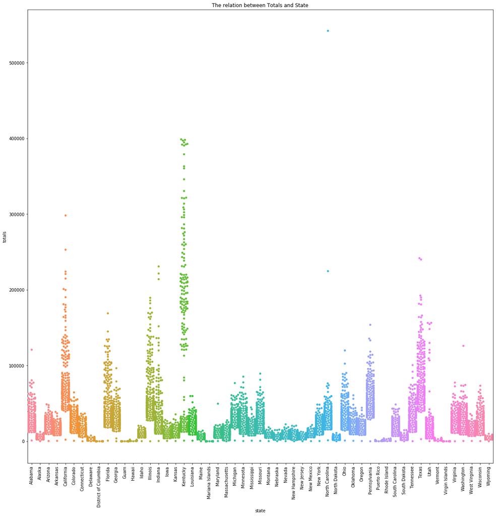

```python
plt.subplots(figsize=(20,20))
plt.xticks(rotation=90);
plt.title('The relation between Totals and State')
sns.swarmplot(x='state', y='totals', data=guns_df);
```

```python
registered_gun.idxmax()
```

```
'Kentucky'
```

**the overall trend of gun purchases**

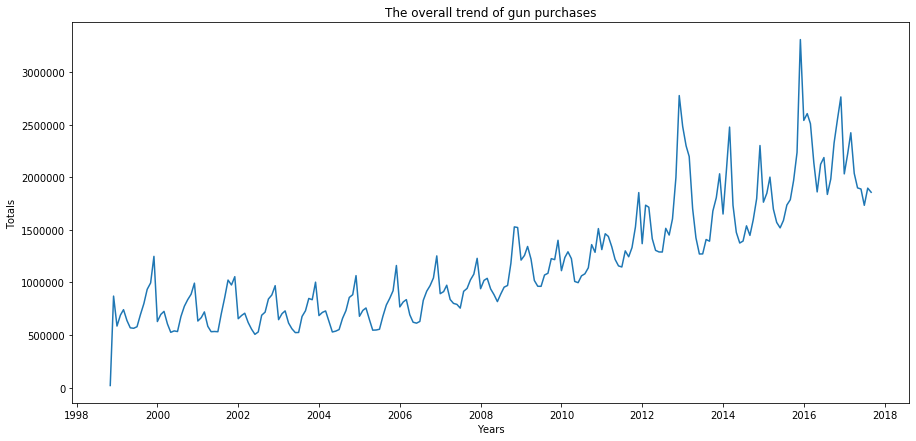

```python
gun_trend =guns_df.groupby(['month'])['totals'].sum()
f, size = plt.subplots(figsize=(15, 7))
plt.xlabel("Years")
plt.ylabel("Totals")
sns.lineplot(data = gun_trend,ax=size).set(title='The overall trend of gun purchases');
```

## Conclusions

> After studying and analyzing the datasets, a good amount of informations has been collected. the dataset contains 2 tables, they should to be gathered into different dataframes. The data was in between 1998 to 2017, which expalin information about types of gun and who can permit guns.

> **First question** is about '*Which highest state in permit?*' in this question we use guns data of all the states to know in each state the largest permits number approved and the **Kentucky** was the highest state in permit was **24926779**

> **Third question** is about '*Which month in the year have highest permit of guns?*' in this question we use the data of guns and extract months from month column after converted it to datetime data type, then groupby months to sum all permits for each month, so the largest permits was in **March** with permits **8306293**

> **Fourth question** is about '*What the average of the all firms in 2012 for all states?*' in this question we use census data that all firms in 2012 detailed, and filtered the comma to find the mean of record, that was equal **554891.84**